# Marburg_underreporting

2023-06-12

# Outbreak of Marburg and Ebola

Loading the packages and data

```r
# Load Marburg linelist data
MVD_linelist <- read_csv("Data/Marburg_EqGuinea_linelist.csv")
head(MVD_linelist)
```

```
## # A tibble: 6 × 8
##   Case_id Type      Status    Onset_week Gender Age   Contacts Occupation
##     <dbl> <chr>     <chr>     <date>     <chr>  <chr> <chr>    <chr>
## 1       1 confirmed dead      2023-02-06 F      40-49 unknown  unknown
## 2       2 confirmed dead      2023-02-13 M      40-49 unknown  unknown
## 3       3 confirmed dead      2023-02-20 F      0-9   unknown  unknown
## 4       4 confirmed recovered 2023-03-05 M      40-49 unknown  HCW
## 5       5 confirmed dead      2023-03-05 F      40-49 unknown  HCW
## 6       6 confirmed dead      2023-03-05 F      40-49 unknown  HCW
```

```r
# Load 2022 Ebola data from global.health
# Source: https://github.com/globaldothealth/ebola
ebola_linelist_2022 <- read_csv("https://3mmuwilir3.execute-api.eu-central-1.amazonaws.com/web/url?folder=&file_name=latest.csv")
```

```
## ──────────────────────────────────────────────────────── Delimiter: "," chr
## (23): Pathogen, Case_status, Location_District, Country, Age, Gender, O... dbl
## (2): ID, Contact_ID lgl (24): Previous_infection, Co_infection,
## Pre_existing_condition, Vaccina... date (9): Date_onset, Date_confirmation,
## Date_of_first_consult, Date_hospit...
```

```r
# Load Ebola 1976 linelist data
data_ebola_1976  <- read_csv("Data/ebola_1976_linelist.csv")
```

## Estimating severity in real-time

In real-time, different data streams are available to calculate severity. The two main ones are individual-level data in the form of line lists, and aggregated data in the form of incidence (e.g. cases per day over time).

A key challenge when calculating severity is that in the middle of an outbreak, people may have recently been diagnosed with the disease, but not yet had an outcome, i.e. the delay from onset to death means it is not yet known whether they will recover or die. To calculate severity such as CFR = deaths/cases, we therefore need to consider deaths among those cases who have a known outcome (or we have estimated to have a known outcome), rather than all cases, to avoid underestimating the CFR.

This document illustrates how to estimate the severity of disease depending on the type of data that is available to the user, using the `cfr` package, as well as other relevant packages, by including case studies that use real outbreak data.

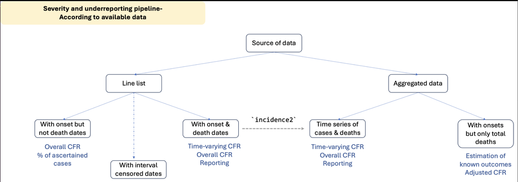

### 1. From linelist with known outcomes

If we have line list data with cases and outcome (i.e. death/recovery/unknown) for individuals, we can simply extract those who have a known outcome and run the CFR calculation on these individuals. This implicitly assumes the delay from onset-to-outcome is independent of outcome (i.e. delay to death and recovery the same), which means individual-level data conditioned on known outcome won’t need further adjustment, even if some outcomes are not yet known, because the ratio of deaths to cases is unbiased if onset-to-death and onset-to-recovery follow the same distribution.

#### Case study: Marburg in Equatorial Guinea, 2023

We compiled data from the Marburg outbreak that took place in Equatorial Guinea from December 2022 until April 2023, including the case type (probable vs confirmed), the status of the case (recovered/dead/unknown), the week of illness onset, and, for some of the cases, information about their gender, age, occupation, and relation to other outbreak cases.

We calculated the deaths among the total number of cases and among confirmed cases only, and estimated the CFR with a simple binomial calculation.

```r
total_MVD_cases <- MVD_linelist %>% summarise(total_cases = length(Onset_week))

total_MVD_confirmed_cases <- MVD_linelist %>% filter(Type == "confirmed") %>% summarise(total_cases = length(Onset_week))

total_MVD_deaths <- MVD_linelist %>% filter(Status == "dead") %>% summarise(total_deaths = length(Onset_week))

total_MVD_confirmed_deaths <- MVD_linelist %>% filter(Status == "dead" & Type == "confirmed") %>% summarise(total_deaths = length(Onset_week))

# Define binomial confidence interval function:
ci_text<-function(x,n){
  bin_out <- binom.test(as.numeric(x),as.numeric(n)); est <- round(100*c(bin_out$estimate,bin_out$conf.int))
  paste(est[1],"% (95% CI: ",est[2],"-",est[3],"%)",sep="")
}

# CFR among total cases
ci_text(total_MVD_deaths, total_MVD_cases)
```

```
## [1] "88% (95% CI: 73-96%)"
```

```r
# CFR among confirmed cases
ci_text(total_MVD_confirmed_deaths,total_MVD_confirmed_cases)
```

```
## [1] "71% (95% CI: 44-90%)"
```

Because of the lack of death dates in the line list, it was not possible to estimate the time-varying CFR, but it was possible to use the information from cases with known outcomes to calculate a single overall CFR.

#### Case study: Ebola in Uganda, 2022

We can apply the same methods to data from the Ebola outbreak in Uganda in mid-2022.

```r
# Estimate CFR for cases with known outcomes
data_ebola <- ebola_linelist_2022 |> mutate(Date_case = as.Date(ifelse(!is.na(Date_onset),Date_onset,Date_confirmation),"1970-01-01"))
data_outcome <- data_ebola |>  filter(!is.na(Date_Death) | !is.na(Date_Recovered))

# Calculate CFR
total_ebola_deaths <- sum(!is.na(data_outcome$Date_Death))
total_ebola_cases <- nrow(data_outcome)
ci_text(total_ebola_deaths,total_ebola_cases)
```

```
## [1] "49% (95% CI: 41-57%)"
```

### Estimating ascertainment of cases

During an outbreak, it is likely that the most severe cases (which would most likely result in death) will be detected and reported, but a proportion of the outbreak cases will not be ascertained.

If a proportion *p* of cases are ascertained, then we can write the observed CFR as:

oCFR = deaths/(cases x *p*)

Hence if the true CFR is

tCFR = deaths/cases

then the proportion of ascertained cases, *p* = tCFR/oCFR.

#### Case study: Marburg in Equatorial Guinea, 2023

For Marburg disease, the overall CFR calculated above was 88%. Based on a systematic review by [Nyakarahuka et al](https://bmcinfectdis.biomedcentral.com/articles/10.1186/s12879-016-2045-6), we assume that the ‘true’ CFR for Marburg is 65% (95% CI: 54-75%).

We can then estimate *p* = tCFR/oCFR as

```r
65/as.numeric(total_MVD_deaths/total_MVD_cases)
```

```
## [1] 74.28571
```

#### Case study: Ebola in Uganda, 2022

For ebola, the overall CFR calculated above was 49%. Based on analysis of a well documented 2001 Uganda outbreak by Omaswa et al, we assume the ‘true’ CFR is 53% (48-58%).

We can then estimate *p* = tCFR/oCFR as

```r
53/as.numeric(total_ebola_deaths/total_ebola_cases)
```

```
## [1] 108.0649
```

Because *p* is greater than 100%, it suggests little underascertainment relative to the 2001 outbreak.

### 2. From case timeseries when number of onsets known but only total deaths

It may be the situation that case onset dates are known, but dates of death are not reported (e.g. in a situation report). This means we must estimate the proportion of cases with a known outcome to perform the CFR calculation.

First, we can use the `extract_param` function in epiparameter to estimate the Marburg onset-to-death delay and store this as an epidist object. Data from [Colebunders et al](https://pubmed.ncbi.nlm.nih.gov/17940943/) was used in this example:

```r
set.seed(1)
extract_param(type = "range", values = c(8, 2, 16), distribution = "gamma", samples = 77)
```

```
## Stochastic numerical optimisation used.
## Rerun function multiple times to check global optimum is found
```

```
##    shape    scale
## 2.094983 4.512825
```

```r
marburg_onset_death <- epidist(disease = "marburg", epi_dist = "onset_to_death", prob_distribution = "gamma", prob_distribution_params = c(shape=2.095, scale=4.513))
```

```
## Citation cannot be created as author, year, journal or title is missing
```

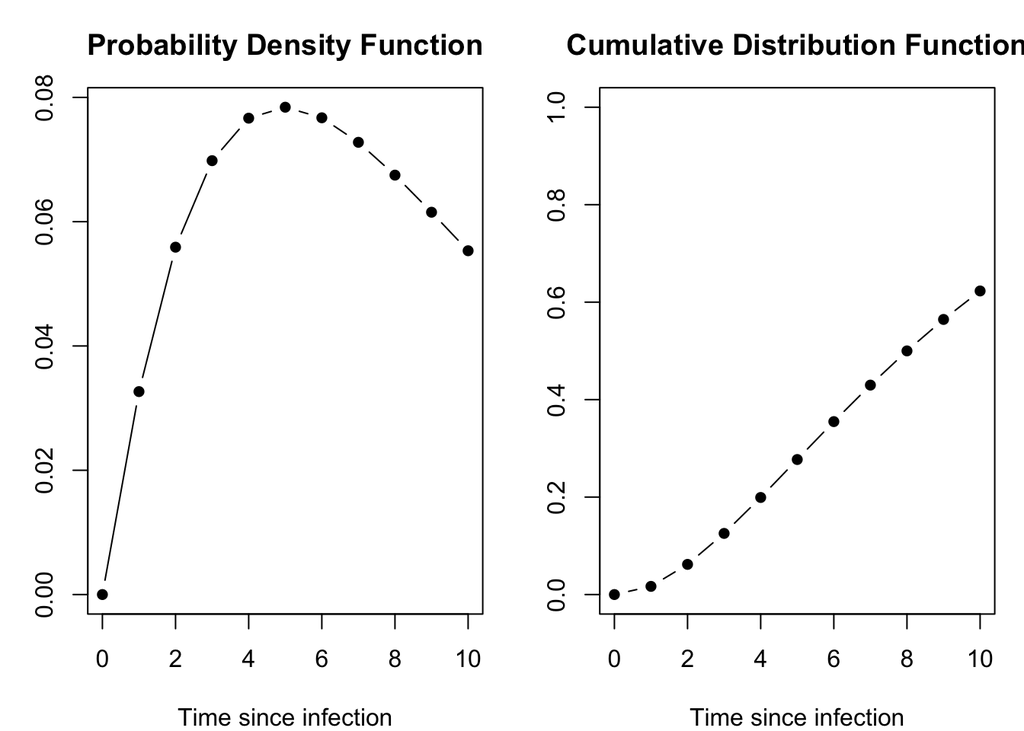

```r
plot(marburg_onset_death)
```

Suppose hypothetically we had a scenario where by 1st March 2023, 18 deaths had been reported in the outbreak. We can therefore use the `estimate_outcomes()` function from `cfr` to estimate the number of cases that have a known outcome by this point, and compare with a ‘naive’ estimate that doesn’t account for delays.

```r
cut_off <- as.Date("2023-03-01") # date to analyse up to in real-time

MVD_linelist_cut <- MVD_linelist |> filter(Onset_week < cut_off)

MVD_linelist_cut$Death_week <- MVD_linelist_cut$Onset_week #Necessary to do this as estimate_outcomes() expects a dataset with 3 columns, including deaths, cases, and date index- even though the deaths column won't be used in the estimation

# Convert to incidence
MVD_cases_deaths <- incidence2::incidence(MVD_linelist_cut,c("Onset_week","Death_week")) %>% complete_dates() #Complete dates to add sequential dates

#Prepare data for {cfr}
MVD_cases_deaths <- cfr::prepare_data(MVD_cases_deaths, cases_variable = "Onset_week", deaths_variable = "Death_week") #Preparing data with {cfr} function, vs the old way to do so, which required to pivot the table

#Estimating the number of cases that are expected to have a known outcome on each day of the outbreak, and then adding them up to have an estimate of the total number of cases with a known outcome up to the cut-off time defined above:

known_outcomes_MVD <- cfr::estimate_outcomes(MVD_cases_deaths, delay_density = function(x) density(marburg_onset_death, x))
total_known_to_date <- sum(known_outcomes_MVD$estimated_outcomes)
total_known_to_date
```

```
## [1] 20.7496
```

This new estimate is used as the denominator when calculating CFR. Below is a comparison between the CFR calculated using the raw number of cases to date, and the number with known outcomes (i.e. adjusting for delays).

```r
# Raw CFR
ci_text(18,sum(MVD_cases_deaths$cases))
```

```
## [1] "75% (95% CI: 53-90%)"
```

```r
# CFR adjusting for delays
ci_text(18,round(total_known_to_date))
```

```
## [1] "86% (95% CI: 64-97%)"
```

### 3. From case and death timeseries

If we have the full incidence data for of cases and deaths available, we can also use `cfr` to estimate the CFR, adjusting for delay from onset to outcome. An example with the 1976 Ebola dataset is reported in the [cfr vignette](https://epiverse-trace.github.io/cfr/articles/estimate_static_severity.html), but here we show how this method performs against the ‘ground truth’ of subsequent known outcomes in the line list, as well as an alternative estimation method based on `EpiNow2`.

First, we load the development version of `EpiNow2`, which allows estimation of the proportion of infection events with a given characteristic (i.e. fatal outcome) at a given delay. We also define the Ebola onset-to-death using `epiparameter`:

```r
#pak::pak("epiforecasts/EpiNow2")
library(EpiNow2)
onset_to_death_ebola <- epiparameter::epidist_db(
  disease = "Ebola Virus Disease",
  epi_dist = "onset_to_death",
  author = "WHO-Ebola-Response-Team")
```

[output not shown]

First we estimate the CFR based on the line list data up to 5th October 1976. We perform two calculations: 1) Estimate CFR based only on cases with known outcomes up to this date. 2) Estimate a ‘ground truth’ CFR with the benefit of hindsight by following up all cases that had onsets prior to this date, but outcomes that were not necessarily known by 5th October:

```r
cut_off <- as.Date("1976-10-05") # date to analyse up to in real-time

# Calculate CFR based on line list and ground truth

df_ll_subset_onset <- subset(data_ebola_1976, disease_onset <= cut_off) # onsets up to cut off

df_ll_subset_outcome <- subset(data_ebola_1976, disease_ended <= cut_off) # outcomes up to cut off

# Estimate CFR based on known outcomes in real-time
CFR_binomial_RT_ll <- ci_text(sum(df_ll_subset_outcome$status=="died"), nrow(df_ll_subset_outcome))

# Estimate CFR based on future follow ups of known onsets
CFR_binomial_ll_true <- ci_text(sum(df_ll_subset_onset$status=="died"), nrow(df_ll_subset_onset))
```

Next, we convert the Ebola line list to case and death incidence (as it might appear in a summary report, or aggregated dataset), focusing on data up to 5th October:

```r
# Convert cases and deaths to incidence series
case_data <- incidence2::incidence(data_ebola_1976,c("disease_onset")) |> complete_dates() |> rename(cases = count,date=date_index) |> dplyr::select(cases,date)

data_ebola_died <- data_ebola_1976 |> filter(status=="died")
death_data <- incidence2::incidence(data_ebola_died, "disease_ended") |> complete_dates() |> rename(deaths = count,date=date_index) |> dplyr::select(deaths,date)

data_ebola_ts <- merge(case_data,death_data,all=T) # merge timeseries
data_ebola_ts[is.na(data_ebola_ts)] <- 0 # replace NA with zero counts

# Define subset of data for analysis
df_ebola_subset <- subset(data_ebola_ts, date <= cut_off)
```

We then estimate the overall CFR with `cfr` and `EpiNow2`, with and without adjusting for delays:

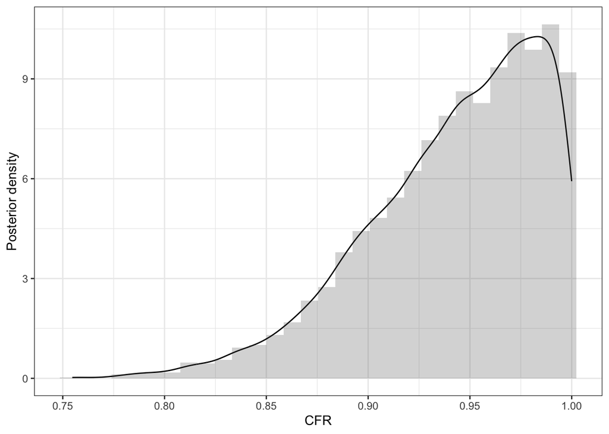

```r
# Calculate real-time overall CFR with cfr, without adjusting for delays
dt_ncfr_static_ebola <- cfr::cfr_static(
  df_ebola_subset)

# Calculate real-time overall CFR with cfr, adjusting for delays
dt_ccfr_static_ebola <- cfr::cfr_static(
  df_ebola_subset,
  delay_density = function(x) density(marburg_onset_death, x))

# Fit with EpiNow2
# Get parameters from epiparameter and format for EpiNow2
param_ebola <- epiparameter::get_parameters(onset_to_death_ebola)

onset_to_death_meansd <- epiparameter::convert_params_to_summary_stats(
   distribution = "gamma",
  shape = param_ebola[["shape"]],
  scale = param_ebola[["scale"]]
)

onset_to_death_logmean <- EpiNow2::convert_to_logmean(
  mean = onset_to_death_meansd[["mean"]],
  sd = onset_to_death_meansd[["sd"]]
)

onset_to_death_logsd <- EpiNow2::convert_to_logsd(
  mean = onset_to_death_meansd[["mean"]],
  sd = onset_to_death_meansd[["sd"]]
)

# Format data for fitting
data_epinow2 <- df_ebola_subset |> rename(primary = cases, secondary = deaths)

# Estimate CFR

delay <- dist_spec(mean = onset_to_death_logmean,
    mean_sd = 0.1,
    sd = 0.59,
    sd_sd = 0.1,
    max = 21,
    distribution = "lognormal",
    prior_weight = 1)

cases_to_deaths <- EpiNow2::estimate_secondary(
  data_epinow2,
  delays = delay_opts(delay),
  secondary = secondary_opts(type = "incidence"),
  obs = obs_opts(
    scale = list(mean = 0.5, sd = 10),
    family = "poisson",
    week_effect = FALSE
  ),
  verbose = FALSE
)

# Plot outputs
cfr_samples <- rstan::extract(cases_to_deaths$fit, "frac_obs")[[1]][, 1]

tibble(cfr = cfr_samples) |>
  ggplot(aes(x = cfr)) +
  geom_density() +
  geom_histogram(aes(y = after_stat(density)), alpha = 0.25) +
  theme_bw() +
  xlab("CFR") +
  ylab("Posterior density")
```

```r
dt_epinow2 <- 100*quantile(cfr_samples, c(0.5, 0.025, 0.975)) |> signif(3)
dt_ccfr_static_ebola_epinow2 <- paste0(dt_epinow2[1],"% (95% CI: ",dt_epinow2[2],"-",dt_epinow2[3],")")
```

Finally, we collate the above estimates and compare them:

```r
# Compare line list, cfr and EpiNow2 estimates for CFR:
dt_static_clean_ebola <- rbind(c(dt_ncfr_static_ebola$severity_me,"naive incidence calculation"),                    c(dt_ccfr_static_ebola$severity_me,"cfr adjusted estimate"),                               c(dt_ccfr_static_ebola_epinow2,"EpiNow2 estimate"),
                               c(CFR_binomial_RT_ll,"Based on known line list outcomes in real-time"),
                               c(CFR_binomial_ll_true,"Based on subsequent known line list outcomes of real-time onsets (i.e. ground truth)"))

dt_static_clean_ebola
```

```
##      [,1]
## [1,] "0.811926605504587"
## [2,] "1"
## [3,] "95% (95% CI: 84-99.8)"
## [4,] "98% (95% CI: 94-99%)"
## [5,] "95% (95% CI: 92-98%)"
##      [,2]
## [1,] "naive incidence calculation"
## [2,] "cfr adjusted estimate"
## [3,] "EpiNow2 estimate"
## [4,] "Based on known line list outcomes in real-time"
## [5,] "Based on subsequent known line list outcomes of real-time onsets (i.e. ground truth)"
```